# An Introduction to FastqCleaner

Documentation of the function

- **fixed_filter**

Removes the specified number of bases from 3’ or 5’.

```r
# create sequences, qualities and names of width 20
set.seed(10)
input <- random_seq(6, 20)
input
```

```
##   A DNAStringSet instance of length 6
##     width seq
## [1]    20 TGGTCCGGTGTTCTGGCGGA
## [2]    20 ATAGGTACAGTCCAGTAATT
## [3]    20 GCCTCCCGCAGACGCTGGGT
## [4]    20 CCGGAATGCCCTTTCTGAGC
## [5]    20 AGCTCCAGCCGTTTGACTTC
## [6]    20 GCGGAAAGTGAACTTAGATT
```

```r
set.seed(10)
input_q <- random_qual(c(30,40), slength = 6, swidth = 20,
    encod = "Sanger")

input_names <- seq_names(6)

# create ShortReadQ object
my_read <- ShortReadQ(sread = input, quality = input_q, id = input_names)

# apply the filter
filtered3 <- fixed_filter(my_read, trim5 = 5)
sread(filtered3)
```

```
##   A DNAStringSet instance of length 6
##     width seq
## [1]    15 TGGTCCGGTGTTCTG
## [2]    15 ATAGGTACAGTCCAG
## [3]    15 GCCTCCCGCAGACGC
## [4]    15 CCGGAATGCCCTTTC
## [5]    15 AGCTCCAGCCGTTTG
## [6]    15 GCGGAAAGTGAACTT
```

```r
filtered5 <- fixed_filter(my_read, trim3 = 5)
sread(filtered5)
```

```
##   A DNAStringSet instance of length 6
##     width seq
## [1]    15 CGGTGTTCTGGCGGA
## [2]    15 TACAGTCCAGTAATT
## [3]    15 CCGCAGACGCTGGGT
## [4]    15 ATGCCCTTTCTGAGC
## [5]    15 CAGCCGTTTGACTTC
## [6]    15 AAGTGAACTTAGATT
```

```r
filtered3and5 <- fixed_filter(my_read, trim3 = 10, trim5 = 5)
sread(filtered3and5)
```

```
##   A DNAStringSet instance of length 6
##     width seq
## [1]     5 TTCTG
## [2]     5 TCCAG
## [3]     5 GACGC
## [4]     5 CTTTC
## [5]     5 GTTTG
## [6]     5 AACTT
```

Documentation of the function

- **length_filter**

Removes sequences with a length lower than minimum threshold value or/and higher than a maximum threshold value.

```r
# create  ShortReadQ object width widths between 1 and 60
set.seed(10)
input <- random_length(10, widths = 1:60)
sread(input)
```

```
##   A DNAStringSet instance of length 10
##      width seq
##  [1]    43 TCTGGCGGAATAGGTACAGTCCAGTAATTGCCTCCCGCAGACG
##  [2]     9 CTGGGTCCG
##  [3]    10 GAATGCCCTT
##  [4]    48 TCTGAGCAGCTCCAGCCGTTTGACTTCGCGGAAAGTGAACTTAGATTC
##  [5]    12 GGTCCTGAAACA
##  [6]    55 CGGTACTTCCACAGTCAACCCGCCGACTTGGAGAATTTATTAGCCGGGCGGTTAT
##  [7]     8 TCCCCTAG
##  [8]    54 TGATCTTACTAAGATTTGCAATACCTAAGCGAAGTGACAGATATGTTCGTCATT
##  [9]    39 CATCCAGGCAAGTGCGCGGACATCAATTACCACACAATT
## [10]    19 AAATATGACTCGCGTATCG
```

```r
# apply the filter, removing sequences with length < 5 or length> 30
filtered <- length_filter(input, rm.min = 5, rm.max = 30)
sread(filtered)
```

```
##   A DNAStringSet instance of length 5
##     width seq
## [1]     9 CTGGGTCCG
## [2]    10 GAATGCCCTT
## [3]    12 GGTCCTGAAACA
## [4]     8 TCCCCTAG
## [5]    19 AAATATGACTCGCGTATCG
```

Documentation of the function

- **n_filter**

Wrapper of the *ShortRead* nFilter function. Removes all those sequences with a number of N’s > a given threshold.

```r
# create 10 sequences of width 20
set.seed(10)
input <- random_seq(10, 20)
input
```

```
##   A DNAStringSet instance of length 10
##      width seq
##  [1]    20 TGGTCCGGTGTTCTGGCGGA
##  [2]    20 ATAGGTACAGTCCAGTAATT
##  [3]    20 GCCTCCCGCAGACGCTGGGT
##  [4]    20 CCGGAATGCCCTTTCTGAGC
##  [5]    20 AGCTCCAGCCGTTTGACTTC
##  [6]    20 GCGGAAAGTGAACTTAGATT
##  [7]    20 CGGTCCTGAAACACGGTACT
##  [8]    20 TCCACAGTCAACCCGCCGAC
##  [9]    20 TTGGAGAATTTATTAGCCGG
## [10]    20 GCGGTTATTCCCCTAGTGAT
```

```r
# inject N's
set.seed(10)
input <- inject_letter_random(input, how_many_seqs = 1:5,
    how_many = 1:10)
input
```

```
##   A DNAStringSet instance of length 10
##      width seq
##  [1]    20 TGGTCCGGTGTTCTGGCGGA
##  [2]    20 ATAGGTACAGTCCAGTAATT
##  [3]    20 GCCTCCCGCAGACGCTGGGT
##  [4]    20 CCGGAATGCCCTTTCTGAGC
##  [5]    20 AGCTCCAGCCGTTTGACTTC
##  [6]    20 GCGGAAAGTGAACTTAGATT
##  [7]    20 CNGTCNNNAANCNNNNTACN
##  [8]    20 NCCANANTCAACNCGCCNAC
##  [9]    20 TTGGAGNATNTATTNGCNNN
## [10]    20 GCGGTTATTCCCCTAGTGAT
```

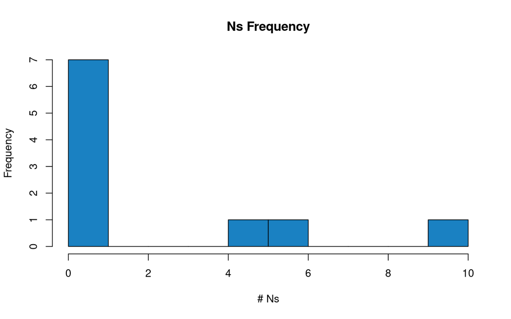

```r
#'
hist(letterFrequency(input, "N"), breaks = 0:10,
    main  = "Ns Frequency", xlab = "# Ns",
    col = "#1a81c2")
```

**Figure 15**: N’s histogram for the sequences before the filtering operation

```r
# Create qualities, names and ShortReadQ object
set.seed(10)
input_q <- random_qual(10, 20)
input_names <- seq_names(10)
my_read <- ShortReadQ(sread = input, quality = input_q, id = input_names)

# Apply the filter
filtered <- n_filter(my_read, rm.N = 3)
sread(filtered)
```

```
##   A DNAStringSet instance of length 7
##     width seq
## [1]    20 TGGTCCGGTGTTCTGGCGGA
## [2]    20 ATAGGTACAGTCCAGTAATT
## [3]    20 GCCTCCCGCAGACGCTGGGT
## [4]    20 CCGGAATGCCCTTTCTGAGC
## [5]    20 AGCTCCAGCCGTTTGACTTC
## [6]    20 GCGGAAAGTGAACTTAGATT
## [7]    20 GCGGTTATTCCCCTAGTGAT
```

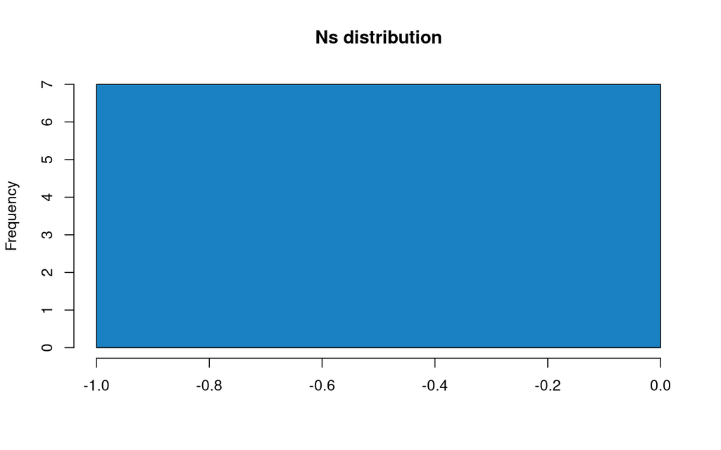

```r
hist(letterFrequency(sread(filtered), "N"),
    main = "Ns distribution", xlab = "",
    col = "#1a81c2")
```

**Figure 16**: N’s histogram for the sequences after the filtering operation

Documentation of the function

- **qmean_filter**

Removes those sequences with quality < a give threshold.

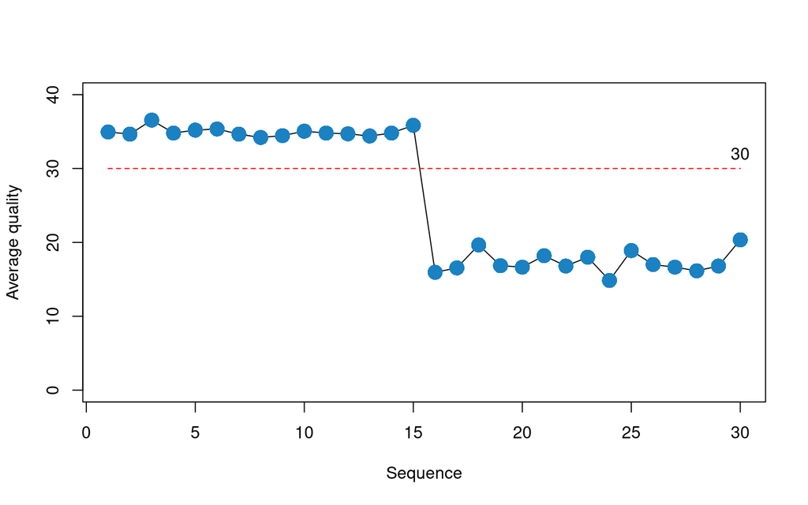

```r
# create 30 sequences of width 20, 15 with low quality and 15 with high quality
set.seed(10)
input <- random_seq(30, 20)

set.seed(10)
my_qual_H <- random_qual(c(30,40), slength = 15, swidth = 20,
    encod = "Sanger")

set.seed(10)
my_qual_L <- random_qual(c(5,30), slength = 15, swidth = 20,
    encod = "Sanger")
input_q<- c(my_qual_H, my_qual_L)

input_names <- seq_names(30)
my_read <- ShortReadQ(sread = input, quality = input_q, id = input_names)

# Plot of average qualities
qual_plot <- function(x, cutoff) {
q <- alphabetScore(x) / width(x)
plot(q, type="l", xlab = "Sequence", ylab= "Average quality", ylim = c(0, 40))
points(q, col = "#1a81c2", pch = 16, cex = 2)
lines(seq_along(q), rep(cutoff, length(q)), type="l", col = "red", lty=2)
text(length(q), cutoff+2, cutoff)
}

#' Average qualities before
qual_plot(my_read, cutoff = 30)
```

**Figure 17**: Average qualities before the filtering operation

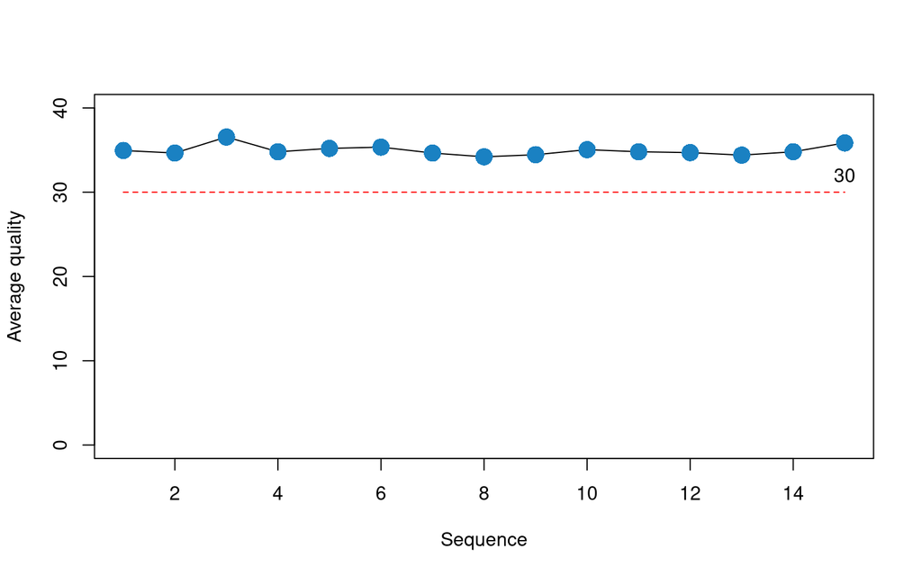

```r
# Apply the filter
filtered <- qmean_filter(my_read, minq = 30)

# Average qualities after
qual_plot(filtered, cutoff = 30)
```

**Figure 18**: Average qualities after the filtering operation

Documentation of the function

- **seq_filter**

Removes sequences that match those passed as argument.

```r
# Generate random sequences
set.seed(10)
input <- random_length(30, 3:7)

# Remove sequences that contain the following patterns:
rm.seq  = c("TGGTC", "CGGT", "GTTCT", "ATA")
match_before <- unlist(lapply(rm.seq, function(x) grep(x,
as.character(sread(input)))))
match_before
```

```
## [1] 14 17 27
```

```r
filtered <- seq_filter(input,rm.seq =  rm.seq)

# Verify that matching sequences were removed
match_after <- unlist(lapply(rm.seq, function(x) {
                grep(x, as.character(sread(filtered)))}))
match_after
```

[output not shown]

Documentation of the function

- **trim3q_filter**

Removes from the 3’ ends in-tandem nucleotides with a quality < a threshold value.

```r
# Create 6 sequences of width 20
set.seed(10)
input <- random_seq(6, 20)
input
```

```
##   A DNAStringSet instance of length 6
##     width seq
## [1]    20 TGGTCCGGTGTTCTGGCGGA
## [2]    20 ATAGGTACAGTCCAGTAATT
## [3]    20 GCCTCCCGCAGACGCTGGGT
## [4]    20 CCGGAATGCCCTTTCTGAGC
## [5]    20 AGCTCCAGCCGTTTGACTTC
## [6]    20 GCGGAAAGTGAACTTAGATT
```

```r
# Create Phred+33 qualities of width 15 and paste to qualities of length
# 5 used for the tails.
# for three of the sequences, put low qualities in tails
set.seed(10)
my_qual <- random_qual(c(30,40), slength = 6, swidth = 15,
    encod = "Sanger")
set.seed(10)
tails <-   random_qual(c(30,40), slength = 6, swidth = 5,
    encod = "Sanger")

# Low quality tails in sequences 2, 3 & 4
set.seed(10)
tails[2:4] <- random_qual(c(3, 20), slength = 3, swidth = 5,
    encod = "Sanger")
my_qual <- paste0(my_qual, tails)
input_q <- BStringSet(my_qual)
input_q
```

```
##   A BStringSet instance of length 6
##     width seq
## [1]    20 EGFEDIBEH@C@DD?EAAID
## [2]    20 I?EGDHIBEG?BHFG,%),4
## [3]    20 ACCFBBFCI?I@HBC402+,
## [4]    20 CGIAFGB@?AIDF@I14)2+
## [5]    20 IB@ACAAC?AGEDDHC?BEB
## [6]    20 BH?GFFHHG?DABECFEEDE
```

```r
# Watch qualities before filtering
as.matrix(PhredQuality(input_q))
```

```
##      [,1] [,2] [,3] [,4] [,5] [,6] [,7] [,8] [,9] [,10] [,11] [,12] [,13] [,14]
## [1,]   36   38   37   36   35   40   33   36   39    31    34    31    35    35
## [2,]   40   30   36   38   35   39   40   33   36    38    30    33    39    37
## [3,]   32   34   34   37   33   33   37   34   40    30    40    31    39    33
## [4,]   34   38   40   32   37   38   33   31   30    32    40    35    37    31
## [5,]   40   33   31   32   34   32   32   34   30    32    38    36    35    35
## [6,]   33   39   30   38   37   37   39   39   38    30    35    32    33    36
##      [,15] [,16] [,17] [,18] [,19] [,20]
## [1,]    30    36    32    32    40    35
## [2,]    38    11     4     8    11    19
## [3,]    34    19    15    17    10    11
## [4,]    40    16    19     8    17    10
## [5,]    39    34    30    33    36    33
## [6,]    34    37    36    36    35    36
```

```r
# Create names and ShortReadQ object
input_names <- seq_names(6)
my_read <- ShortReadQ(sread = input, quality = input_q, id = input_names)

# Apply the filter
filtered <- trim3q_filter(my_read, rm.3qual = 28)
sread(filtered)
```

```
##   A DNAStringSet instance of length 6
##     width seq
## [1]    20 TGGTCCGGTGTTCTGGCGGA
## [2]    15 ATAGGTACAGTCCAG
## [3]    15 GCCTCCCGCAGACGC
## [4]    15 CCGGAATGCCCTTTC
## [5]    20 AGCTCCAGCCGTTTGACTTC
## [6]    20 GCGGAAAGTGAACTTAGATT
```

Documentation of the function

- **unique_filter**

Wrapper of the *ShortRead* occurrenceFilter function. that removes duplicated sequences.

```r
# Create duplicated sequences
s <- random_seq(10, 10)
s <- sample(s, 30, replace = TRUE)

# Create a ShortReadQ object
q <- random_qual(30, 10)
n <- seq_names(30)
my_read <- ShortReadQ(sread = s, quality = q, id = n)

# Check presence of duplicates
isUnique(as.character(sread(my_read)))
```

```
##  [1] FALSE FALSE FALSE FALSE FALSE FALSE FALSE FALSE FALSE FALSE FALSE FALSE
## [13] FALSE FALSE FALSE FALSE FALSE FALSE FALSE FALSE FALSE FALSE FALSE FALSE
## [25] FALSE FALSE FALSE FALSE FALSE  TRUE
```

```r
# Apply the filter
filtered <- unique_filter(my_read)
isUnique(as.character(sread(filtered)))
```

```
##  [1] TRUE TRUE TRUE TRUE TRUE TRUE TRUE TRUE TRUE TRUE
```

Documentation of the function

## 4.2 Auxiliary functions

- **random_seq**

Create a vector of random sequences, for a set of specificied parameters.

Documentation of the function

- **random_qual**

Create a vector of random qualities for a given encoding and a set of specified parameters.

Documentation of the function

- **seq_names**

Create a vector of names for a set of sequences.

Documentation of the function

- **random_length**

Create a set of sequences with random lengths.

Documentation of the function

- **inject_letter_random**

Inject a character (e.g., ‘N’) at random positions, given a set of parameters.

Documentation of the function

- **check_encoding**

The function allows to check quality encoding. It detects encodings with the following formats:

[output not shown]

Documentation of the function

# 5 Contact information

Mantainer: Leandro Roser - learoser@gmail.com